# Final Project Report

```python
# Import relevant libraries
import numpy as np
import matplotlib.pyplot as plt
plt.style.use('seaborn')
plt.rcParams["figure.figsize"] = (20,10)

from scipy import stats
import statsmodels.api as sm

%matplotlib inline
```

# Problem 1

```python
gold2=[193, 305, 615, 459, 375, 424, 361, 317, 368, 446, 437, 381, 384, 362, 344, 360, 384, 384, 388, 331,
294, 279, 279, 271, 310, 363, 409, 444, 604, 695, 872, 972, 1225, 1572, 1669, 1411, 1266]


gold=[5.264967387, 5.719262046, 6.420808929, 6.129616498, 5.927725706, 6.048931247,
5.888268354, 5.759847699, 5.907675246, 6.100812104, 6.079612778, 5.942326823, 5.949496062,
5.892362186, 5.840496298, 5.885603906, 5.951033101, 5.950772752, 5.960670232, 5.802994125,
5.683885843, 5.629669374, 5.631570141, 5.602266411, 5.735539506, 5.895283989, 6.014130718,
6.096837563, 6.403193331, 6.544472839, 6.770743551, 6.879715822, 7.110304209, 7.359798583,
7.41996794, 7.252216944, 7.143933509]

lag = gold[:-1]
gold_t = gold[1:]

beta, alpha, r_value, p_value, std_err = stats.linregress(gold_t, lag)
```

The above is the provided code. Let's have a look at the data first.

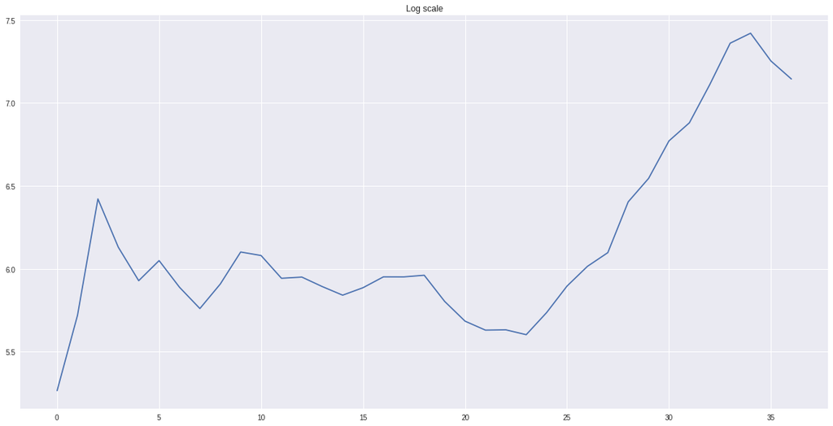

```python
#%% do some plotting
plt.figure(figsize=(20,10))
plt.title('Log scale')
plt.plot(gold)
```

[output not shown]

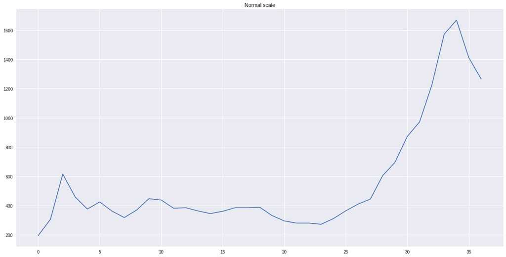

```python
plt.figure(figsize=(20,10))
plt.plot(gold2)
plt.title('Normal scale')
plt.draw
```

## Regression results

```python
print("Estimated alpha: " + str(alpha) + " Estimated beta: " + str(beta))
print("R-squared: " + str(r_value**2))
print("p_value: " + str(round(p_value, 5)))

forecast_gold = np.exp(alpha+beta*gold[-1])
print("Forecasted value for next time period: " + str(forecast_gold))
```

```
Estimated alpha: 0.428123903567 Estimated beta: 0.922226946193
R-squared: 0.868737862694
p_value: 0.0
Forecasted value for next time period: 1114.82407076
```

The results are somewhat limited and it is difficult to interpret them so I implemented the model in statsmodel package below.

```python
np_lag = np.array(lag)
np_gold_t = np.array(gold_t)
np_lag = sm.add_constant(np_lag, prepend=True)
results = sm.OLS(np_gold_t, np_lag).fit()
print(results.summary())
```

```
                            OLS Regression Results
==============================================================================
Dep. Variable:                      y   R-squared:                       0.869
Model:                            OLS   Adj. R-squared:                  0.865
Method:                 Least Squares   F-statistic:                     225.0
Date:                Tue, 05 Sep 2017   Prob (F-statistic):           1.48e-16
Time:                        23:11:10   Log-Likelihood:                 8.9141
No. Observations:                  36   AIC:                            -13.83
Df Residuals:                      34   BIC:                            -10.66
Df Model:                           1
Covariance Type:            nonrobust
==============================================================================
                 coef    std err          t      P>|t|      [0.025      0.975]
------------------------------------------------------------------------------
const          0.4074      0.386      1.056      0.299      -0.377       1.192
x1             0.9420      0.063     15.001      0.000       0.814       1.070
==============================================================================
Omnibus:                       10.138   Durbin-Watson:                   1.234
Prob(Omnibus):                  0.006   Jarque-Bera (JB):                9.400
Skew:                           0.993   Prob(JB):                      0.00910
Kurtosis:                       4.523   Cond. No.                         75.1
==============================================================================

Warnings:
[1] Standard Errors assume that the covariance matrix of the errors is correctly specified.
```

There are small differences in the regression as the data set was treated little differently. We can see that the intercept paramenter is not statistically significant. The plot below is the forecast for this fit.

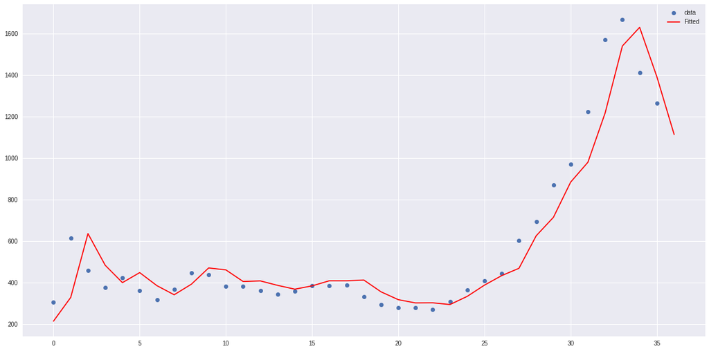

```python
fig, ax = plt.subplots(figsize=(20,10))
ax.plot(np.exp(np_gold_t), 'o', label='data')
ax.plot(np.exp(np.append(results.fittedvalues, np.log(forecast_gold))), 'r-', label='Fitted')
ax.legend(loc='best')
plt.draw()
```

```python
# I removed the constant from the estimation as it was not statistically significant.
np_lag = np.array(lag)
np_gold_t = np.array(gold_t)
#np_lag = sm.add_constant(np_lag, prepend=True)
results = sm.OLS(np_gold_t, np_lag).fit()
print(results.summary())
```

```
                            OLS Regression Results
==============================================================================
Dep. Variable:                      y   R-squared:                       0.999
Model:                            OLS   Adj. R-squared:                  0.999
Method:                 Least Squares   F-statistic:                 3.645e+04
Date:                Tue, 05 Sep 2017   Prob (F-statistic):           2.05e-54
Time:                        23:11:17   Log-Likelihood:                 8.3336
No. Observations:                  36   AIC:                            -14.67
Df Residuals:                      35   BIC:                            -13.08
Df Model:                           1
Covariance Type:            nonrobust
==============================================================================
                 coef    std err          t      P>|t|      [0.025      0.975]
------------------------------------------------------------------------------
x1             1.0081      0.005    190.914      0.000       0.997       1.019
==============================================================================
Omnibus:                       12.310   Durbin-Watson:                   1.285
Prob(Omnibus):                  0.002   Jarque-Bera (JB):               13.160
Skew:                           1.067   Prob(JB):                      0.00139
Kurtosis:                       5.054   Cond. No.                         1.00
==============================================================================

Warnings:
[1] Standard Errors assume that the covariance matrix of the errors is correctly specified.
```

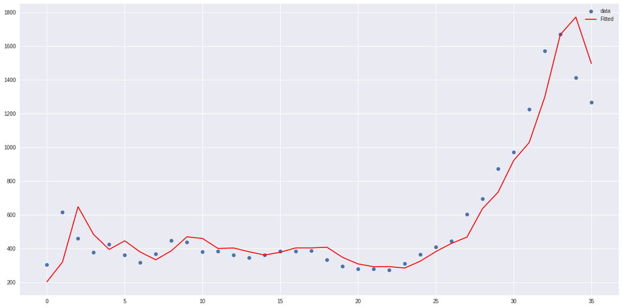

```python
fig, ax = plt.subplots(figsize=(20,10))
ax.plot(np.exp(np_gold_t), 'o', label='data')
ax.plot(np.exp(results.fittedvalues ), 'r-', label='Fitted')
ax.legend(loc='best')
plt.draw()
```

## Discussion for Problem 1

We can see that the better model for the given dataset is the one without the alpha intercept. It has much higher R-squared and the beta parameter is statistically significant. We see that the beta value is slightly above one. This means that the model assumes always some small incease over the previous values. Obviously, it fails to forecasts well if this is not the case as it the last few periods. However, the high R-squared really shows that the previous values is really important when forecasting the series. It seems we do have serial correlation at play here.

# Problem 2

My approach towards this problem will be to collect some data that may be relevant and I will try different models. As many as I can. We can than compare them and pick the best model methodology.

```python
import statsmodels.api as sm
from statsmodels.tsa.stattools import adfuller as adf
from statsmodels.graphics.tsaplots import plot_acf, plot_pacf
from statsmodels.graphics.api import qqplot
import scipy.stats as scs
from arch import arch_model

import pandas as pd
import numpy as np

import matplotlib.pyplot as plt
import matplotlib as mpl
import seaborn as sns


plt.style.use('seaborn')
plt.rcParams["figure.figsize"] = (20,10)
cm = plt.cm.get_cmap('RdYlBu')
%matplotlib inline
```

# Data Descriptions

I used ETF from Yahoo finance that mirrors gold. I used the daily Adjusted Close series. I choose to work with the dates 2013-05-01 to 2017-09-01 as it simplifies the problem. I looked at the whole history initially however the history is too log and there is too much going on over last 20 years.

```python
df_data = pd.read_csv('GLD.csv',index_col=0)
df_data = df_data.loc['2013-05-01':'2017-09-01']
df_AC = df_data.AdjClose
df_AC_diff = df_AC.diff().dropna()
df_returns = df_AC.pct_change().dropna()
df_log_returns = np.log(df_AC)-np.log(df_AC.shift(1))
df_log_returns.dropna(inplace=True)
```

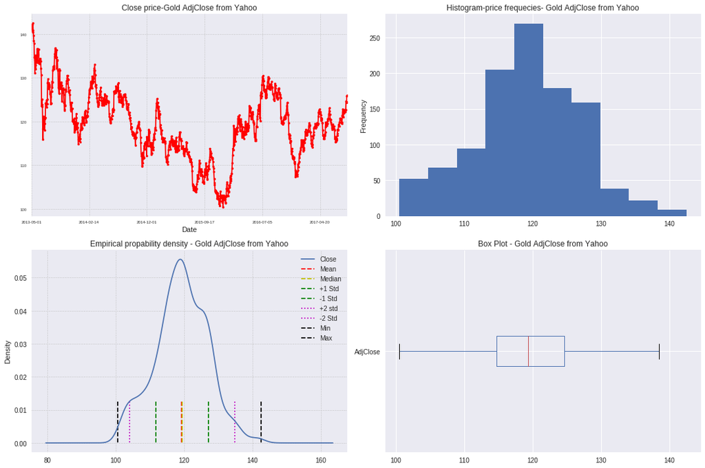

```
Descriptive statistics for Gold AdjClose from Yahoo are:
count    1095.000000
mean      119.190557
std         7.685980
min       100.500000
25%       114.720001
50%       119.349998
75%       124.559998
max       142.460007
Name: AdjClose, dtype: float64
```

```python
describe_series(df_AC, 'Gold AdjClose from Yahoo')
```

```python
df_returns.describe()
```

```
count    1094.000000
mean       -0.000055
std         0.009853
min        -0.053526
25%        -0.005330
50%        -0.000086
75%         0.004938
max         0.049038
Name: AdjClose, dtype: float64
```

```python
df_log_returns.describe()
```

```
count    1094.000000
mean       -0.000103
std         0.009853
min        -0.055012
25%        -0.005344
50%        -0.000086
75%         0.004926
max         0.047874
Name: AdjClose, dtype: float64
```

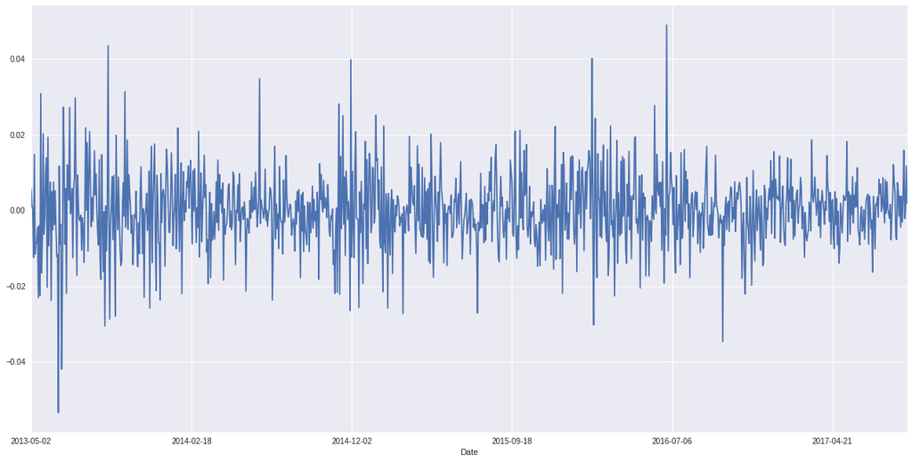

```python
plt.figure(figsize=(20,10))
df_returns.plot()
plt.draw()
```

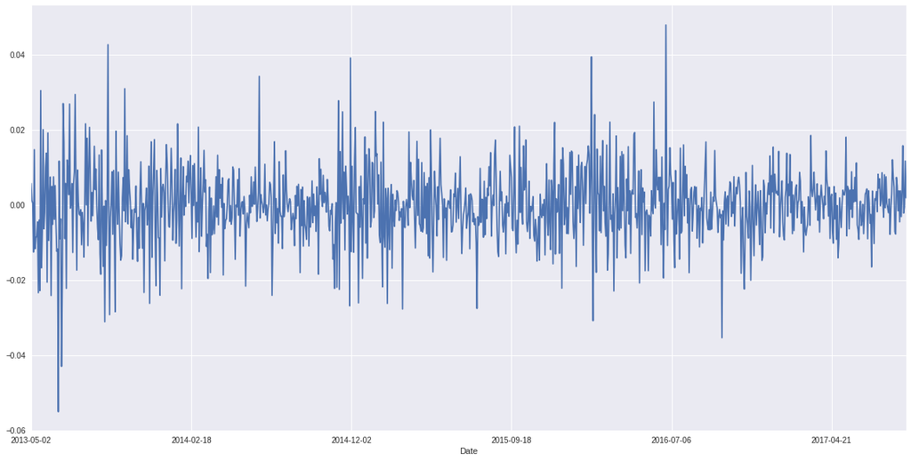

```python
plt.figure(figsize=(20,10))
df_log_returns.plot()
plt.draw()
```

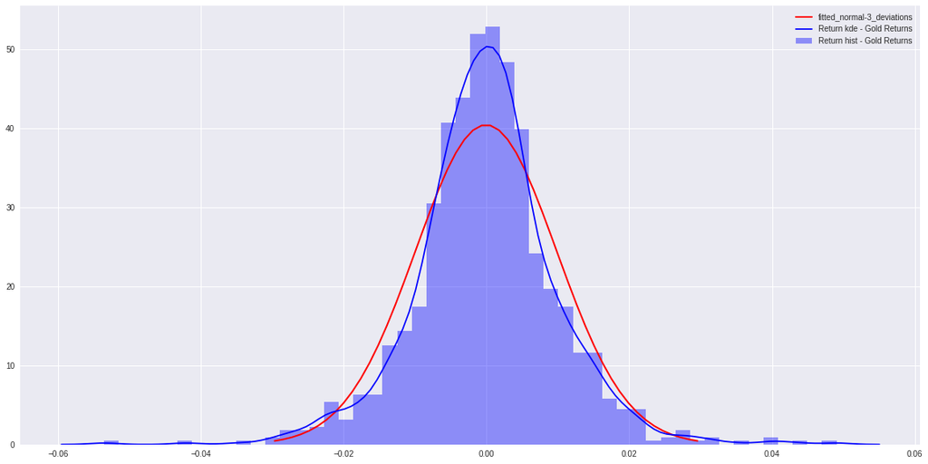

```python
plot_hist(df_returns.values, 'Gold Returns')
```

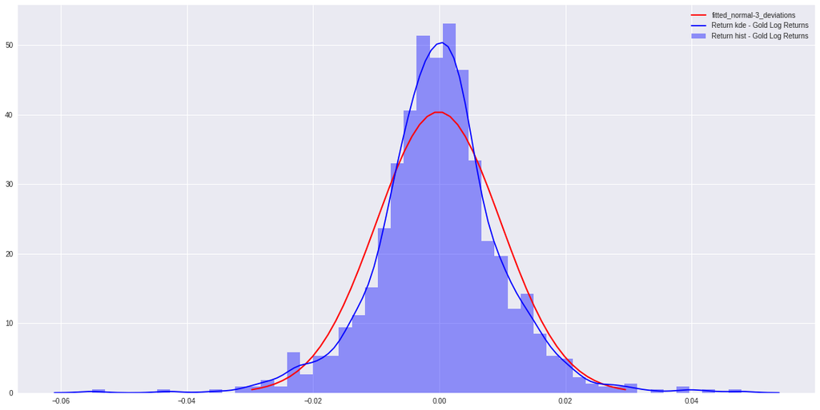

```python
plot_hist(df_log_returns.values, 'Gold Log Returns')
```

We can compare the log returns and the normal returns. It seems that both log returns and the normal returns are almost identical from the statistical perspective. Both return sets are not normal.

# ADF Test

We will test it for stationarity used ADF test.

```python
# test the original series
results = adf(df_AC.values.ravel())
print_ADF_results(results, 0.05)
```

```
Test Statistic: -2.88804
p value: 0.04676
Number of lags used: 10
Number of observations used for the ADF regression and calculation of the critical values: 1084
Critical values for the test statistic at the 1 %, 5 %, and 10 % levels. Based on MacKinnon (2010): {'1%': -3.4363969122132692, '5%': -2.8642099630802869, '10%': -2.5681915787162484}
The maximized information criterion if autolag is not None: 3356.39082

The above series is likely stationary at 0.05 confidence.
```

Basically, what this means that that the gold prices are I(0) stationary. This took me a while to figure. It is expected that the differences of series are I(0) but this is not the case. In addition, this series is stationary in the sample I picked. If we would change the time period, we could get different series that is not stationary.

Let's test the difference series anyway.

```python
results = adf(df_AC_diff.values.ravel())
print_ADF_results(results, 0.05)
```

```
Test Statistic: -11.13106
p value: 0.00000
Number of lags used: 9
Number of observations used for the ADF regression and calculation of the critical values: 1084
Critical values for the test statistic at the 1 %, 5 %, and 10 % levels. Based on MacKinnon (2010): {'1%': -3.4363969122132692, '5%': -2.8642099630802869, '10%': -2.5681915787162484}
The maximized information criterion if autolag is not None: 3360.61617

The above series is likely stationary at 0.05 confidence.
```

The difference series is stationary as well however the problem is the below. We have no serial correlations in the differences. So, we can't use ARMA model over the differences of the series. We have to use ARMA model for the actual series.

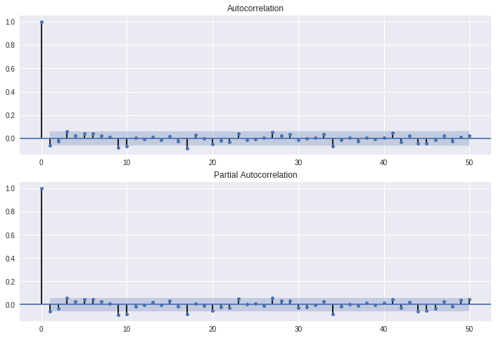

```python
fig = plt.figure(figsize=(12,8))
ax1 = fig.add_subplot(211)
fig = plot_acf(df_AC_diff, lags=50, ax=ax1)
ax2 = fig.add_subplot(212)
fig = plot_pacf(df_AC_diff, lags=50, ax=ax2)
```

Let's see if there is any significant autocorrelation in the actual series.

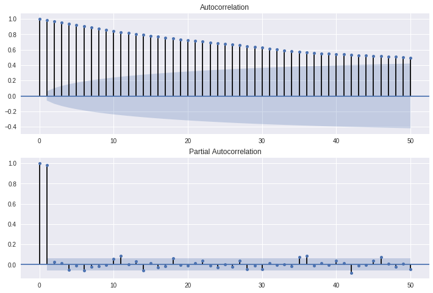

```python
fig = plt.figure(figsize=(12,8))
ax1 = fig.add_subplot(211)
fig = plot_acf(df_AC, lags=50, ax=ax1)
ax2 = fig.add_subplot(212)
fig = plot_pacf(df_AC, lags=50, ax=ax2)
```

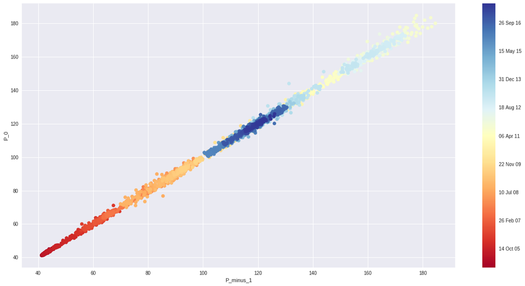

```python
# Plot the serial correlation
df_data = pd.read_csv('GLD.csv',index_col=0)
df_data.index = pd.to_datetime(df_data.index)
df_data = df_data.AdjClose
df_data = pd.concat([df_data,df_data.shift(-1)], axis = 1).dropna()
df_data.columns = ['P_0','P_minus_1']

mpl_dates = mpl.dates.date2num(df_data.index.date)
plt.figure(figsize=(20,10))
plt.scatter(df_data['P_minus_1'], df_data['P_0'], c=mpl_dates, marker='o', cmap=cm)
plt.xlabel('P_minus_1')
plt.ylabel('P_0')
plt.colorbar(ticks=mpl.dates.DayLocator(interval=500), format=mpl.dates.DateFormatter('%d %b %y'))
```

The above plot show the evolution of the time dependence of the series. We can see how the relationship changes over time if we assume price at t-1 determines the price at t.

# ARIMA model

We can see that we have AR and possibly one MA autocorrelation in the series. One option to model the dynamics of the price is ARMA(2,1). It is one of the best fits that I found. Other lags are also possible to take into account however the statsmodels packages is not very flexible in estimating the best fit. I run a number of ARMA models and the below is one of the best ones.

```python
arma = sm.tsa.ARIMA(df_AC.values, (2,0,1)).fit(disp=False, trend='nc')
print(arma.summary())
```

```
                              ARMA Model Results
==============================================================================
Dep. Variable:                      y   No. Observations:                 1095
Model:                     ARMA(2, 1)   Log Likelihood               -1742.795
Method:                       css-mle   S.D. of innovations              1.183
Date:                Tue, 05 Sep 2017   AIC                           3493.590
Time:                        20:05:41   BIC                           3513.584
Sample:                             0   HQIC                          3501.155

==============================================================================
                 coef    std err          z      P>|z|      [0.025      0.975]
------------------------------------------------------------------------------
ar.L1.y        1.0978      0.000   7208.466      0.000       1.097       1.098
ar.L2.y       -0.0978      0.000   -643.215      0.000      -0.098      -0.098
ma.L1.y       -0.1578      0.030     -5.309      0.000      -0.216      -0.100
                                    Roots
=============================================================================
                 Real           Imaginary           Modulus         Frequency
-----------------------------------------------------------------------------
AR.1            1.0000           +0.0000j            1.0000            0.0000
AR.2           10.2227           +0.0000j           10.2227            0.0000
MA.1            6.3386           +0.0000j            6.3386            0.0000
-----------------------------------------------------------------------------
```

# GARCH Model

```python
am = arch_model(df_AC, mean='AR', lags=1, vol='GARCH', dist='StudentsT')
res = am.fit()
print("\n")
print(res.summary())
```

[output not shown]

[output cut: 19 more lines]

```
                              Volatility Model
============================================================================
                 coef    std err          t      P>|t|      95.0% Conf. Int.
----------------------------------------------------------------------------
omega          0.0102  5.074e-03      2.020  4.338e-02 [3.047e-04,2.019e-02]
alpha[1]       0.0261  7.563e-03      3.445  5.712e-04 [1.123e-02,4.088e-02]
beta[1]        0.9649  8.063e-03    119.679      0.000     [  0.949,  0.981]
                              Distribution
========================================================================
                 coef    std err          t      P>|t|  95.0% Conf. Int.
------------------------------------------------------------------------
nu             5.3626      0.836      6.413  1.423e-10 [  3.724,  7.001]
========================================================================

Covariance estimator: robust
```

This GARCH model is superior to the ARMA model as it has lower AIC and it handles Student's t distribution in the estimation. This way we are capturing fat tails in the process.

Let's see if the residuals from this model are normal.

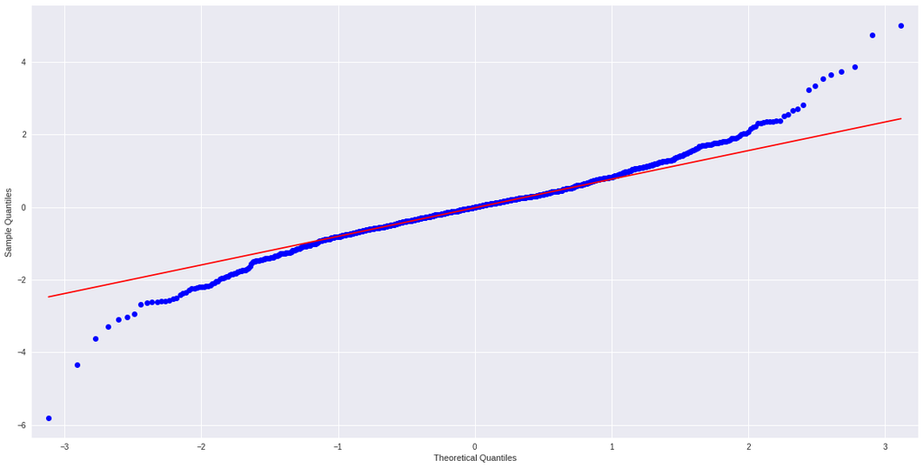

```python
fig = plt.figure(figsize=(20,10))
ax = fig.add_subplot(111)
fig = qqplot(res.resid.dropna(), line='q', ax=ax, fit=True)
```

```python
print("This is D’Agostino and Pearson’s test for normality - H0: normality, low p_value means reject null")
scs.normaltest(res.resid.dropna())
```

```
This is D’Agostino and Pearson’s test for normality - H0: normality, low p_value means reject null
```

```
NormaltestResult(statistic=84.636149153875706, pvalue=4.1830564603773235e-19)
```

## Forecasting using GARCH is done below

```python
forecasts = res.forecast(horizon=3,
                start=1090,
                align='origin',
                method='analytic')


print("Print the conditional mean")
print(forecasts.mean.tail(5))

print("Print the conditional standard deviation.")
print(np.sqrt(forecasts.variance.tail(5)))
```

```
Print the conditional mean
                   h.1         h.2         h.3
Date
2017-08-28  124.613644  124.538078  124.463294
2017-08-29  124.346438  124.273641  124.201598
2017-08-30  124.287063  124.214881  124.143447
2017-08-31  125.731932  125.644776  125.558524
2017-09-01  125.969443  125.879826  125.791137
Print the conditional standard deviation.
                 h.1       h.2       h.3
Date
2017-08-28  0.850201  1.197717  1.461248
2017-08-29  0.841862  1.186053  1.447120
2017-08-30  0.833153  1.173873  1.432368
2017-08-31  0.860979  1.212792  1.479509
2017-09-01  0.853437  1.202243  1.466730
```

# Other Methods

I have tried to use other methods as suggested in the assignment however it didn't work out with any presentable results.

# Function

```python
def plot_hist(array=np.array(0), set_name='set_name'):
    """
    Plots the histogram for data - an array object.
    Normal distribution fit is add

    :REMEMBER: Assumes that if the data point is zero then there was no trading and so it is filtered out.
    """
    array = array[array!=0]

    with mpl.rc_context():
        mpl.rc("figure", figsize=(20,10))

        plt.figure()
        x = np.linspace(array.mean() - 3 * array.std(),
                            array.mean() + 3 * array.std())

        plt.plot(x,
                 scs.norm.pdf(x, array.mean(), array.std()),
                 'r',
                 lw=2.0,
                 label='fitted_normal-3_deviations')

        sns.distplot(array,
                      color='b',
                      kde_kws={"label": "Return kde - " + set_name},
                      hist_kws={"label": "Return hist - " + set_name})

        plt.draw()

    return None

def describe_series(pd_series, set_name):
    """
    Returns descriptive statistics for pandas series object

    :param pd_series: pd.Series object - carries all data
    :param set_name: str - you can use this to set up custom name for plots
    :return: None
    """
    assert isinstance(pd_series, pd.Series), "Pass in a 'pd.Series' object to 'pd_series' variable when calling 'describe_series' function"
    assert isinstance(set_name, str), "Pass in a string variable to 'set_name' parameter when calling 'describe_series' function"

    np_series_values = pd_series.values

    line_size = .1
    if len(np_series_values) < 10:
        line_size = .25
    elif len(np_series_values) < 50:
        line_size = .20
    elif len(np_series_values) <= 100:
        line_size = .00125
    elif len(np_series_values) > 900:
        line_size = .0125
    elif len(np_series_values) > 400:
        line_size = .02
    elif len(np_series_values) > 150:
        line_size = .05
    elif len(np_series_values) > 120:
        line_size = .06
    elif len(np_series_values) > 100:
        line_size = .08

#    line_size = 0.0005

    fig, axes = plt.subplots(nrows=2, ncols=2, figsize=(15, 10))

    pd_series.plot(ax=axes[0, 0], title='Close price-' + str(set_name),  marker='.', color='r')
    axes[0, 0].tick_params(labelsize=6)
    axes[0, 0].grid(b=True, which='major', color='0.75', linestyle='dotted')

    pd_series.plot(ax=axes[0, 1], kind='hist', title='Histogram-price frequecies- ' + str(set_name))
    pd_series.plot.box(ax=axes[1, 1], vert=False, title='Box Plot - ' + str(set_name))
    pd_series.plot(ax=axes[1, 0], kind='density', title='Empirical propability density - ' + str(set_name),
                   linestyle='-')
    axes[1, 0].vlines(np_series_values.mean(), line_size, 0, color='r', linestyle='dashed', label='Mean')
    axes[1, 0].vlines(np.median(np_series_values), line_size, 0, color='y', linestyle='dashed', label='Median')
    axes[1, 0].vlines(np.median(np_series_values) + np.std(np_series_values), line_size, 0, color='g',
                      linestyle='dashed', label='+Std')
    axes[1, 0].vlines(np.median(np_series_values) - np.std(np_series_values), line_size, 0, color='g',
                      linestyle='dashed', label='-Std')
    axes[1, 0].vlines(np.median(np_series_values) + 2 * np.std(np_series_values), line_size, 0, color='m',
                      linestyle='dotted', label='+2Std')
    axes[1, 0].vlines(np.median(np_series_values) - 2 * np.std(np_series_values), line_size, 0, color='m',
                      linestyle='dotted', label='-2Std')
    axes[1, 0].vlines(np.min(np_series_values), line_size, 0, color='k', linestyle='dashed', label='Min')
    axes[1, 0].vlines(np.max(np_series_values), line_size, 0, color='k', linestyle='dashed', label='Min')
    axes[1, 0].grid(b=True, which='major', color='0.75', linestyle='dotted')
    axes[1, 0].legend(['Close', 'Mean', 'Median', '+1 Std', '-1 Std', '+2 std', '-2 Std', 'Min', 'Max'],
                      loc='best')

    plt.tight_layout()
    plt.show()

    del line_size, np_series_values
    print("\nDescriptive statistics for " + set_name + " are:")
    print(pd_series.describe())
    return None

def print_ADF_results(results, critical_value):
    """
    prints out the results with some comments for ADF test
    """
    # http://www.statsmodels.org/stable/generated/statsmodels.tsa.stattools.adfuller.html
    print("\nTest Statistic: " + "%.5f" % results[0])
    print("p value: " + "%.5f" % results[1])
    print("Number of lags used: " + "%.0f" % results[2])
    print("Number of observations used for the ADF regression and calculation of the critical values: " + "%.0f" % results[3])
    print("Critical values for the test statistic at the 1 %, 5 %, and 10 % levels. Based on MacKinnon (2010): " + str(results[4]))
    print("The maximized information criterion if autolag is not None: "  + "%.5f" % results[5])

    if results[1] < critical_value:
        print("\nThe above series is likely stationary at " + str(critical_value) + " confidence.")
    else:
        print("\nThe above series is unlikely stationary at " + str(critical_value) + " confidence.")
```